# Máster en Data Science para Finanzas

### Podemos analizar también variables a nivel individual

```python
def plot_feature(col_name, isContinuous):
    """
    Visualize a variable with and without faceting on the loan status.
    - col_name is the variable name in the dataframe
    - full_name is the full variable name
    - continuous is True if the variable is continuous, False otherwise
    """
    f, (ax1, ax2) = plt.subplots(nrows=1, ncols=2, figsize=(12,3), dpi=90)

    # Plot without loan status
    if isContinuous:
        sns.distplot(df.loc[df[col_name].notnull(), col_name], kde=False, ax=ax1)
    else:
        sns.countplot(df[col_name], order=sorted(df[col_name].unique()), color='#5975A4', saturation=1, ax=ax1)
    ax1.set_xlabel(col_name)
    ax1.set_ylabel('Count')
    ax1.set_title(col_name)
    plt.xticks(rotation = 90)

    # Plot with loan status
    if isContinuous:
        sns.boxplot(x=col_name, y='loan_status', data=df, ax=ax2)
        ax2.set_ylabel('')
        ax2.set_title(col_name + ' by Loan Status')
    else:
        data = df.groupby(col_name)['loan_status'].value_counts(normalize=True).to_frame('proportion').reset_index()
        sns.barplot(x = col_name, y = 'proportion', hue= "loan_status", data = data, saturation=1, ax=ax2)
        ax2.set_ylabel('Loan fraction')
        ax2.set_title('Loan status')
        plt.xticks(rotation = 90)
    ax2.set_xlabel(col_name)

    plt.tight_layout()
```

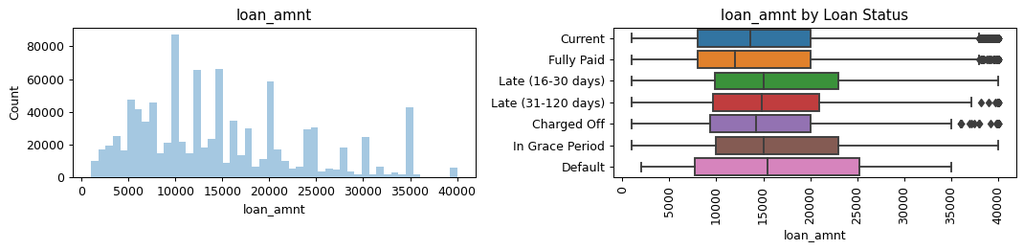

```python
plot_feature('loan_amnt', True)
```

Recuerda que todo lo que haces tiene que tener una justificación. Ahora tocaría explicar qué información de valor podemos sacar de los gráficos anteriores.

Es probable que tengas que limpiar el dataset para poder analizarlo correctamente. Esto implica hacer cambios de tipos de datos por ejemplo, convertir toda una columna a entero, etc.

```python
df.describe()
```

|  | member_id | loan_amnt | funded_amnt | funded_amnt_inv | installment | annual_inc | dti | delinq_2yrs | fico_range_low | fico_range_high | inq_last_6mths | mths_since_last_delinq | mths_since_last_record | open_acc | pub_rec | revol_bal | total_acc | out_prncp | out_prncp_inv | total_pymnt | total_pymnt_inv | total_rec_prncp | total_rec_int | total_rec_late_fee | recoveries | collection_recovery_fee | last_pymnt_amnt | last_fico_range_high | last_fico_range_low | … |
| --- | --- | --- | --- | --- | --- | --- | --- | --- | --- | --- | --- | --- | --- | --- | --- | --- | --- | --- | --- | --- | --- | --- | --- | --- | --- | --- | --- | --- | --- | --- |
| count | 0.0 | 981655.000000 | 981655.000000 | 981655.000000 | 981655.000000 | 9.816550e+05 | 981361.000000 | 981655.000000 | 981655.000000 | 981655.000000 | 981655.000000 | 503935.000000 | 174205.000000 | 981655.000000 | 981655.000000 | 9.816550e+05 | 981655.000000 | 981655.000000 | 981655.000000 | 981655.000000 | 981655.000000 | 981655.000000 | 981655.000000 | 9.816550e+05 | 981655.000000 | 981655.000000 | 981655.000000 | 981655.000000 | 981655.000000 | … |
| mean | NaN | 14963.557767 | 14963.557767 | 14958.494068 | 441.567492 | 7.766029e+04 | 18.878278 | 0.348926 | 694.888999 | 698.889131 | 0.595004 | 33.648506 | 69.144181 | 11.816029 | 0.230210 | 1.700362e+04 | 24.999027 | 5414.467766 | 5412.834903 | 10759.329230 | 10755.536718 | 8402.339152 | 2251.174242 | 9.008020e-01 | 104.915034 | 17.860589 | 3114.646693 | 687.342490 | 676.984434 | … |
| std | NaN | 8864.677646 | 8864.677646 | 8861.664737 | 257.896445 | 1.452782e+05 | 11.822292 | 0.929949 | 31.052538 | 31.053181 | 0.896238 | 21.902016 | 26.371930 | 5.600335 | 0.632749 | 2.309086e+04 | 12.009993 | 7732.201869 | 7730.071883 | 9380.494413 | 9377.202323 | 7961.514874 | 2493.168743 | 7.342317e+00 | 615.556027 | 107.546193 | 5782.015117 | 68.563702 | 101.006471 | … |
| min | NaN | 1000.000000 | 1000.000000 | 900.000000 | 14.010000 | 0.000000e+00 | -1.000000 | 0.000000 | 660.000000 | 664.000000 | 0.000000 | 0.000000 | 0.000000 | 0.000000 | 0.000000 | 0.000000e+00 | 2.000000 | 0.000000 | 0.000000 | 0.000000 | 0.000000 | 0.000000 | 0.000000 | -9.500000e-09 | 0.000000 | 0.000000 | 0.000000 | 0.000000 | 0.000000 | … |
| 25% | NaN | 8000.000000 | 8000.000000 | 8000.000000 | 255.450000 | 4.650000e+04 | 12.320000 | 0.000000 | 670.000000 | 674.000000 | 0.000000 | 15.000000 | 51.000000 | 8.000000 | 0.000000 | 6.229000e+03 | 16.000000 | 0.000000 | 0.000000 | 3259.195868 | 3258.380000 | 2030.270000 | 631.675000 | 0.000000e+00 | 0.000000 | 0.000000 | 301.150000 | 659.000000 | 655.000000 | … |
| 50% | NaN | 13000.000000 | 13000.000000 | 13000.000000 | 377.510000 | 6.500000e+04 | 18.190000 | 0.000000 | 685.000000 | 689.000000 | 0.000000 | 30.000000 | 70.000000 | 11.000000 | 0.000000 | 1.162900e+04 | 23.000000 | 1156.760000 | 1156.620000 | 8236.280000 | 8233.170000 | 6000.000000 | 1388.420000 | 0.000000e+00 | 0.000000 | 0.000000 | 530.610000 | 694.000000 | 690.000000 | … |
| 75% | NaN | 20000.000000 | 20000.000000 | 20000.000000 | 582.350000 | 9.240000e+04 | 24.720000 | 0.000000 | 710.000000 | 714.000000 | 1.000000 | 49.000000 | 88.000000 | 15.000000 | 0.000000 | 2.070800e+04 | 32.000000 | 8872.570000 | 8868.050000 | 15584.175704 | 15577.320000 | 12000.000000 | 2916.655000 | 0.000000e+00 | 0.000000 | 0.000000 | 2541.770000 | 729.000000 | 725.000000 | … |
| max | NaN | 40000.000000 | 40000.000000 | 40000.000000 | 1719.830000 | 1.100000e+08 | 999.000000 | 42.000000 | 845.000000 | 850.000000 | 6.000000 | 188.000000 | 121.000000 | 93.000000 | 86.000000 | 2.904836e+06 | 169.000000 | 40000.000000 | 40000.000000 | 60179.739076 | 60179.740000 | 40000.000000 | 26082.830000 | 5.320800e+02 | 36578.540000 | 6584.137200 | 41453.070000 | 850.000000 | 845.000000 | … |

El análisis de correlaciones es muy importante, ayuda a detectar variables que no pueden estar. Por ejemplo, una variable con más de un 68% (por decir algo) de correlación con la variable target... raro, es posible, pero raro, prácticamente solo con esta variable ya aciertas el target.

OJO, **no procede estudiar correlaciones de Pearson de variables categóricas**, no tiene ningún sentido por la propia fórmula. Hay método para analizar relaciones entre variables categóricas (https://medium.com/@outside2SDs/an-overview-of-correlation-measures-between-categorical-and-continuous-variables-4c7f85610365)

Las variables categóricas se pueden estudiar también analizando valores posibles, frecuencia de estos valores, etc.

```python
corr = df.corr(method = 'spearman')
```

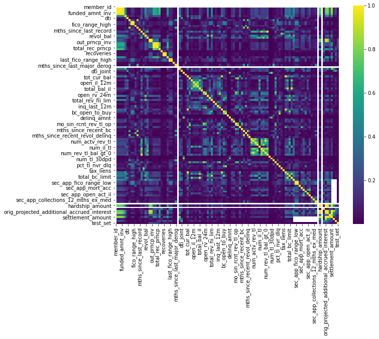

```python
plt.figure(figsize = (10, 8))
sns.heatmap(corr.abs(), cmap ='viridis' )
plt.show()
```

### Find highly correlated features

```python
new_corr = corr.abs()
new_corr.loc[:,:] = np.tril(new_corr, k=-1) # below main lower triangle of an array
new_corr = new_corr.stack().to_frame('correlation').reset_index().sort_values(by='correlation', ascending=False)
```

```python
new_corr[new_corr.correlation > 0.6]
```

|  | level_0 | level_1 | correlation |
| --- | --- | --- | --- |
| 223 | funded_amnt | loan_amnt | 1.000000 |
| 1007 | fico_range_high | fico_range_low | 1.000000 |
| 10101 | sec_app_fico_range_high | sec_app_fico_range_low | 1.000000 |
| 11763 | settlement_amount | orig_projected_additional_accrued_interest | 1.000000 |
| 11449 | orig_projected_additional_accrued_interest | hardship_amount | 1.000000 |
| 3135 | last_fico_range_low | last_fico_range_high | 1.000000 |
| 2015 | out_prncp_inv | out_prncp | 0.999999 |
| 2239 | total_pymnt_inv | total_pymnt | 0.999998 |
| 335 | funded_amnt_inv | funded_amnt | 0.999899 |
| 334 | funded_amnt_inv | loan_amnt | 0.999899 |
| 8375 | num_sats | open_acc | 0.998386 |
| 2799 | collection_recovery_fee | recoveries | 0.996437 |
| 11764 | settlement_amount | hardship_payoff_balance_amount | 0.994505 |
| 8320 | num_rev_tl_bal_gt_0 | num_actv_rev_tl | 0.989321 |
| 9387 | tot_hi_cred_lim | tot_cur_bal | 0.974560 |
| 2351 | total_rec_prncp | total_pymnt_inv | 0.971517 |
| 2350 | total_rec_prncp | total_pymnt | 0.971508 |
| 445 | installment | loan_amnt | 0.962609 |
| 446 | installment | funded_amnt | 0.962609 |
| 447 | installment | funded_amnt_inv | 0.962419 |
| 9723 | total_il_high_credit_limit | total_bal_il | 0.953095 |
| 11557 | hardship_payoff_balance_amount | hardship_amount | 0.943692 |
| 11559 | hardship_payoff_balance_amount | orig_projected_additional_accrued_interest | 0.942632 |
| 11761 | settlement_amount | hardship_amount | 0.939560 |
| 5867 | avg_cur_bal | tot_cur_bal | 0.925992 |
| 11366 | orig_projected_additional_accrued_interest | out_prncp | 0.904796 |
| 11367 | orig_projected_additional_accrued_interest | out_prncp_inv | 0.904744 |
| 7325 | mths_since_recent_revol_delinq | mths_since_recent_bc_dlq | 0.885760 |
| 9503 | total_bal_ex_mort | total_bal_il | 0.883620 |
| 9404 | tot_hi_cred_lim | avg_cur_bal | 0.880626 |

[output cut: 129 more lines]

Quedaría pendiente aquí por ejemplo hacer un buen estudio de posibles correlaciones con el target

### Histogramas

Muy importantes, para saber cómo se distribuyen las variables.

```python
numeric_features = df.select_dtypes(include=['int32', 'int64', 'float64']).columns
```

```python
numeric_features
```

```
Index(['member_id', 'loan_amnt', 'funded_amnt', 'funded_amnt_inv',
       'installment', 'annual_inc', 'dti', 'delinq_2yrs', 'fico_range_low',
       'fico_range_high',
       ...
       'hardship_amount', 'hardship_length', 'hardship_dpd',
       'orig_projected_additional_accrued_interest',
       'hardship_payoff_balance_amount', 'hardship_last_payment_amount',
       'settlement_amount', 'settlement_percentage', 'settlement_term',
       'test_set'],
      dtype='object', length=112)
```

```python
# Histogram with Kernel Density Estimate Plot (KDE)
# Source: https://stackoverflow.com/questions/43638851/pandas-histogram-plot-with-kde
def plot_histograms(df, columns):
    # keep total number of subplot
    k = len(df.columns)
    # n = number of chart columns
    n = columns
    m = (k - 1) // n + 1

    # Create figure
    fig, axes = plt.subplots(m, n, figsize=(n * 5, m * 3))

    # Iterate through columns, tracking the column name and
    # which number we are at i. Within each iteration, plot
    for i, (name, col) in enumerate(df.iteritems()):
        r, c = i // n, i % n
        ax = axes[r, c]
        # the histogram
        col.hist(ax=ax)
        # kde = Kernel Density Estimate plot
        ax2 = col.plot.kde(ax=ax, secondary_y=True, title=name)
        ax2.set_ylim(0)

    # Use tight_layout() as an easy way to sharpen up the layout spacing
    fig.tight_layout()
```

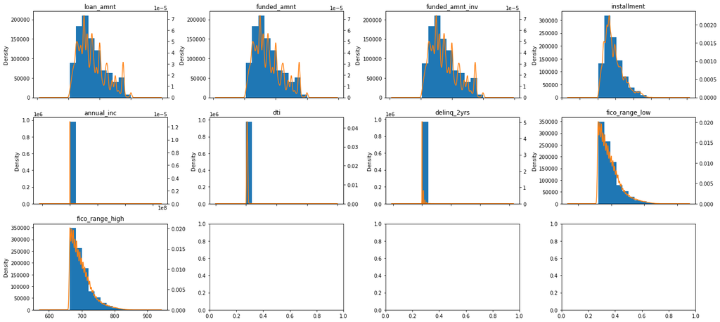

```python
# selecciono algunas como ejemplo, por ejemplo, los ID no hay que incluirlos nunca en el EDA
plot_histograms(df=df[['loan_amnt', 'funded_amnt', 'funded_amnt_inv',
       'installment', 'annual_inc', 'dti', 'delinq_2yrs', 'fico_range_low',
       'fico_range_high']], columns=4)
```

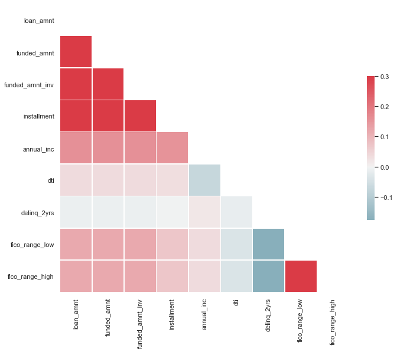

```python
sns.set(style="white")

# Compute the correlation matrix
corr = df[['loan_amnt', 'funded_amnt', 'funded_amnt_inv',
           'installment', 'annual_inc', 'dti', 'delinq_2yrs',
           'fico_range_low','fico_range_high']].corr()

# Generate a mask for the upper triangle
mask = np.zeros_like(corr, dtype=np.bool)
mask[np.triu_indices_from(mask)] = True

# Set up the matplotlib figure
f, ax = plt.subplots(figsize=(11, 9))

# Generate a custom diverging colormap
cmap = sns.diverging_palette(220, 10, as_cmap=True)

# Draw the heatmap with the mask and correct aspect ratio
sns.heatmap(corr, mask=mask, cmap=cmap, vmax=.3, center=0,
            square=True, linewidths=.5, cbar_kws={"shrink": .5})
```

### Tareas que quedarían por hacer

1. Limpieza de datos
2. Imputación de valores nulos cuando corresponda
3. Outliers
4. Ingeniería de variables (por ejemplo, generar una variable día laborable o festivo), One-Hot Encoding
5. Normalización de variables y escalado (revisar apuntes respecto a esto)

# Bloque 2: selección de variables

Ahora vendría la parte de selección de variables. Este enlace contiene información básica: https://machinelearningmastery.com/feature-selection-with-real-and-categorical-data/

Interesa, trabajar con el mínimo conjunto de variables, pero claro **sin perder poder predictivo**. Por eso, esto es una tarea que empieza pero no acaba aquí. Es frecuente trabajar en iteraciones y una vez que tengo un modelo, probar qué métricas obtengo si quitase una variable concreta. Normalmente, ante la duda y si no tengo problemas de rendimiento, calidad de los datos, etc., no solemos arriesgarnos a quitar la variable salvo que tengamos muy claro que no aporta. En resumen, no hay una guía escrita tremendamente detallada que diga con cuántas variables debemos quedarnos en cada caso, aquí debemos experimentar y evaluar distintas alternativas.

Un método sencillo para comenzar (pero no debe ser lo único que se prueba) es Lasso (https://www.yourdatateacher.com/2021/05/05/feature-selection-in-machine-learning-using-lasso-regression/) este algoritmo da pesos a las distintas variables, ordenando los pesos por su valor absoluto, podemos ver qué considera más importante y qué menos. En clase se verán ejemplos de otros algoritmos.

**Recuerda que no todos los algoritmos se pueden aplicar a todos los problemas**. Tenemos que saber qué estamos haciendo, clasificación, regresión... clasificación binaria, multiclase... Puede que haya métodos que solo sean aplicable a una problemática concreta. Para saber esto **hay que leer siempre la documentación de la librería con la implementación del método/algoritmo concreto**. El conocimiento no viene por arte de magia.

A continuación, algo de código de Lasso no para ejecutar, sino para investigar y buscar información en los tutoriales oficiales de from sklearn.linear_model import Lasso, LassoCV: %%time lassocv = LassoCV(alphas = None, # no predefinimos los alphas, queremos que los seleccione el propio modelo cv = 10, # indicamos que el cross validation realice 10K max_iter = 500, # número máximo de iteraciones = 500 normalize = True, # normalizamos las variables random_state = 50) # entrenamos el modelo de cross validation con toda la muestra: lassocv.fit(predictiveVariables, target ,) # valores de alpha seleccionados por el modelo: lassocv.alpha_ # definimos: lasso function, en el que el alpha será el calculado anteriormente model_lasso = Lasso(alpha=lassocv.alpha_) # entrenamos el modelo lasso con toda la muestra model_lasso.fit(predictiveVariables, target) # coefficientes lasso de las variables predictoras: lasso_coefficients = pd.DataFrame(model_lasso.coef_, set(predictiveVariables), columns = ['Coefficients']) # término independiente del modelo Lasso lasso_coefficients.loc['Intercept'] = model_lasso.intercept_ lasso_coefficients # data frame de los coeficientes Lasso df_lasso = pd.DataFrame(lasso_coefficients) # ordenamos las variables en función de sus coeficientes df_lasso_ordered = df_lasso.sort_values(by = "Coefficients")

# Bloque 3: modelado

Llega el momento de comenzar a probar modelos. Lo primero que tenemos que saber es qué tipo de problema tenemos y qué tipos de modelos son candidatos a solución. A partir de ahí, probar. A priori es muy difícil saber con qué modelo vamos a obtener los mejores resultados.

Se empieza por los modelos más fáciles, y se va complicando probando diferentes modelos y analizando si el incremento de complejidad y tiempo de cómputo justifica los resultados.

En caso de clasificación binaria, siempre empezamos por un modelo base "tonto". Lo más fácil posible, que consiste en predecir asignando siempre el mismo valor, que será el valor mayoritario del target. Esto no tiene más utilidad práctica que tener un valor de referencia a mejorar. Cuando trabajamos con conjuntos de datos muy desbalanceado, es muy útil.

Esta referencia puede ser útil

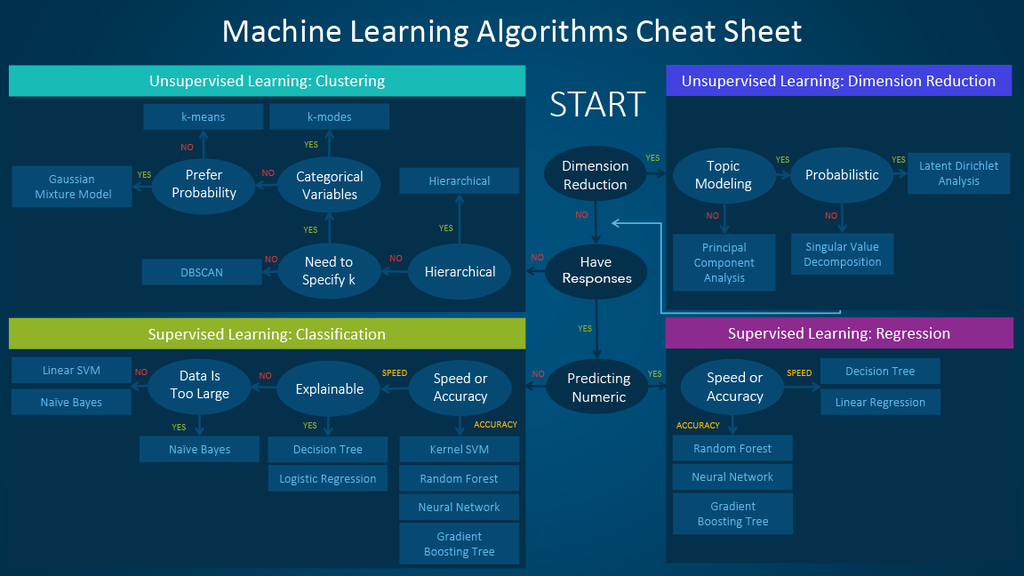

https://blogs.sas.com/content/subconsciousmusings/2020/12/09/machine-learning-algorithm-use/

Aquí tengo que decidir también si empleo alguna técnica de **balanceo de datos** o no. Oversampling, undersampling, SMOTE... Buenas referencias como punto de partida:

https://towardsdatascience.com/imbalanced-classification-in-python-smote-tomek-links-method-6e48dfe69bbc https://machinelearningmastery.com/undersampling-algorithms-for-imbalanced-classification/

A continuación un ejemplo básico solo para que tengas una referencia de código. Recuerda que en una práctica real **debes ir explicando todo lo que haces y los resultados que obtienes**.

```python
import sklearn
from sklearn.pipeline import Pipeline
from sklearn.impute import SimpleImputer
from sklearn.preprocessing import StandardScaler, OneHotEncoder

from sklearn.utils import resample
from sklearn.ensemble import RandomForestClassifier
from sklearn.preprocessing import StandardScaler
from sklearn.model_selection import train_test_split
from sklearn.model_selection import cross_validate, KFold

from sklearn.metrics import classification_report, confusion_matrix, roc_curve, auc, \
                            silhouette_score, recall_score, precision_score, make_scorer, \
                            roc_auc_score, f1_score, precision_recall_curve

from sklearn.metrics import accuracy_score, roc_auc_score, \
                            classification_report, confusion_matrix


from sklearn import metrics
from sklearn.metrics import plot_confusion_matrix
```

```python
from sklearn.linear_model import LogisticRegression
```

```python
#Combining numerical and categorical piepline into one big pipeline horizontally using ColumnTransformer
from sklearn.compose import ColumnTransformer

## No podemos utilizar TransformTargetRegression porque estamos en un modelo de clasificacion
# from 'Y' and 'N' to numeric values
from sklearn.preprocessing import LabelEncoder

from sklearn.metrics import accuracy_score, log_loss
from sklearn.neighbors import KNeighborsClassifier
from sklearn.svm import SVC, LinearSVC, NuSVC
from sklearn.tree import DecisionTreeClassifier
from sklearn.ensemble import RandomForestClassifier, AdaBoostClassifier, GradientBoostingClassifier
from sklearn.discriminant_analysis import LinearDiscriminantAnalysis
from sklearn.discriminant_analysis import QuadraticDiscriminantAnalysis
```

```python
# Leería los datos que ya los tendría preparados
df_selected = pd.read_csv('../data/df_selected.csv')
```

```python
df_selected.describe(include = 'all')
```

|  | loan_amnt | funded_amnt | funded_amnt_inv | term | int_rate | installment | grade | sub_grade | emp_length | home_ownership | annual_inc | verification_status | loan_status | purpose | addr_state | dti | delinq_2yrs | fico_range_low | fico_range_high | open_acc | pub_rec | revol_bal | revol_util | total_acc | initial_list_status | application_type | acc_open_past_24mths | mort_acc | pub_rec_bankruptcies | … |
| --- | --- | --- | --- | --- | --- | --- | --- | --- | --- | --- | --- | --- | --- | --- | --- | --- | --- | --- | --- | --- | --- | --- | --- | --- | --- | --- | --- | --- | --- | --- |
| count | 442335.000000 | 442335.000000 | 442335.000000 | 442335.000000 | 442335.000000 | 442335.000000 | 442335 | 442335 | 442335.000000 | 442335 | 4.423350e+05 | 442335.000000 | 442335.000000 | 442335 | 442335 | 442335.000000 | 442335.000000 | 442335.000000 | 442335.000000 | 442335.000000 | 442335.000000 | 4.423350e+05 | 442335.000000 | 442335.000000 | 442335.000000 | 442335.000000 | 442335.000000 | 442335.000000 | 442335.000000 | … |
| unique | NaN | NaN | NaN | NaN | NaN | NaN | 7 | 35 | NaN | 4 | NaN | NaN | NaN | 14 | 51 | NaN | NaN | NaN | NaN | NaN | NaN | NaN | NaN | NaN | NaN | NaN | NaN | NaN | NaN | … |
| top | NaN | NaN | NaN | NaN | NaN | NaN | C | C1 | NaN | MORTGAGE | NaN | NaN | NaN | debt_consolidation | CA | NaN | NaN | NaN | NaN | NaN | NaN | NaN | NaN | NaN | NaN | NaN | NaN | NaN | NaN | … |
| freq | NaN | NaN | NaN | NaN | NaN | NaN | 124885 | 26548 | NaN | 220364 | NaN | NaN | NaN | 268039 | 64858 | NaN | NaN | NaN | NaN | NaN | NaN | NaN | NaN | NaN | NaN | NaN | NaN | NaN | NaN | … |
| mean | 14566.416856 | 14566.416856 | 14561.066882 | 42.140378 | 13.255884 | 439.935320 | NaN | NaN | 5.767755 | NaN | 7.560386e+04 | 0.296696 | 0.219291 | NaN | NaN | 18.367815 | 0.338063 | 693.172607 | 697.172704 | 11.800118 | 0.238668 | 1.629901e+04 | 53.091530 | 26.038145 | 0.562827 | 0.002258 | 4.795908 | 1.776111 | 0.147868 | … |
| std | 8500.018979 | 8500.018979 | 8496.756229 | 10.472109 | 4.471144 | 252.505972 | NaN | NaN | 3.722447 | NaN | 6.504089e+04 | 0.456802 | 0.413767 | NaN | NaN | 8.726000 | 0.909042 | 30.325347 | 30.325835 | 5.456944 | 0.632504 | 2.232153e+04 | 23.843562 | 12.158772 | 0.496038 | 0.047470 | 3.143748 | 2.089641 | 0.397284 | … |
| min | 1000.000000 | 1000.000000 | 900.000000 | 36.000000 | 5.320000 | 14.010000 | NaN | NaN | 0.000000 | NaN | 1.000000e+02 | 0.000000 | 0.000000 | NaN | NaN | 0.000000 | 0.000000 | 660.000000 | 664.000000 | 1.000000 | 0.000000 | 0.000000e+00 | 0.000000 | 2.000000 | 0.000000 | 0.000000 | 0.000000 | 0.000000 | 0.000000 | … |
| 25% | 8000.000000 | 8000.000000 | 8000.000000 | 36.000000 | 9.990000 | 256.900000 | NaN | NaN | 2.000000 | NaN | 4.560000e+04 | 0.000000 | 0.000000 | NaN | NaN | 12.060000 | 0.000000 | 670.000000 | 674.000000 | 8.000000 | 0.000000 | 5.992000e+03 | 35.400000 | 17.000000 | 0.000000 | 0.000000 | 3.000000 | 0.000000 | 0.000000 | … |
| 50% | 12500.000000 | 12500.000000 | 12500.000000 | 36.000000 | 12.990000 | 378.760000 | NaN | NaN | 6.000000 | NaN | 6.500000e+04 | 0.000000 | 0.000000 | NaN | NaN | 17.840000 | 0.000000 | 685.000000 | 689.000000 | 11.000000 | 0.000000 | 1.115300e+04 | 53.400000 | 24.000000 | 1.000000 | 0.000000 | 4.000000 | 1.000000 | 0.000000 | … |
| 75% | 20000.000000 | 20000.000000 | 20000.000000 | 60.000000 | 15.990000 | 579.720000 | NaN | NaN | 10.000000 | NaN | 9.000000e+04 | 1.000000 | 0.000000 | NaN | NaN | 24.270000 | 0.000000 | 710.000000 | 714.000000 | 15.000000 | 0.000000 | 1.985600e+04 | 71.300000 | 33.000000 | 1.000000 | 0.000000 | 6.000000 | 3.000000 | 0.000000 | … |
| max | 40000.000000 | 40000.000000 | 40000.000000 | 60.000000 | 30.990000 | 1714.540000 | NaN | NaN | 10.000000 | NaN | 8.900060e+06 | 1.000000 | 1.000000 | NaN | NaN | 999.000000 | 39.000000 | 845.000000 | 850.000000 | 90.000000 | 86.000000 | 2.560703e+06 | 892.300000 | 169.000000 | 1.000000 | 1.000000 | 53.000000 | 47.000000 | 12.000000 | … |

Intencionadamente, no vamos a explicar detalladamente el código que viene a continuación, debes hacer el esfuerzo de intentar interpretarlo. Tómalo como **ejemplo de código**, nunca como algo a hacer copy/paste, porque no es un código que se puede extrapolar a cualquier proyecto.

```python
def evaluate_model(ytest, ypred, ypred_proba = None):
    if ypred_proba is not None:
        print('ROC-AUC score of the model: {}'.format(roc_auc_score(ytest, ypred_proba[:, 1])))
    print('Accuracy of the model: {}\n'.format(accuracy_score(ytest, ypred)))
    print('Classification report: \n{}\n'.format(classification_report(ytest, ypred)))
    print('Confusion matrix: \n{}\n'.format(confusion_matrix(ytest, ypred)))
```

```python
df_major = df_selected[df_selected.loan_status == 0]
df_minor = df_selected[df_selected.loan_status == 1]
```

```python
df_minor_upsmapled = resample(df_minor, replace = True, n_samples = 358436, random_state = 12345)
```

```python
df_minor_upsmapled = pd.concat([df_minor_upsmapled, df_major])
```

```python
df_minor_upsmapled.loan_status.value_counts()
```

```
1    358436
0    345335
Name: loan_status, dtype: int64
```

```python
df_minor_upsmapled.dtypes
```

```
loan_amnt               float64
funded_amnt             float64
funded_amnt_inv         float64
term                      int64
int_rate                float64
installment             float64
grade                    object
sub_grade                object
emp_length                int64
home_ownership           object
annual_inc              float64
verification_status       int64
loan_status               int64
purpose                  object
addr_state               object
dti                     float64
delinq_2yrs             float64
fico_range_low          float64
fico_range_high         float64
open_acc                float64
pub_rec                 float64
revol_bal               float64
revol_util              float64
total_acc               float64
initial_list_status       int64
application_type          int64
acc_open_past_24mths    float64
mort_acc                float64
pub_rec_bankruptcies    float64
tax_liens               float64
disbursement_method       int64
issue_month              object
issue_year                int64
earliest_cr_year          int64
credit_history            int64
dtype: object
```

```python
#Defining the steps in the numerical pipeline
numeric_transformer = Pipeline(steps=[
    ('imputer', SimpleImputer(strategy='median')),
    ('scaler', StandardScaler())])

#Defining the steps in the categorical pipeline
categorical_transformer = Pipeline(steps=[
    ('imputer', SimpleImputer(strategy='constant', fill_value='missing')),
    ('onehot', OneHotEncoder(handle_unknown='ignore'))])


#Numerical features to pass down the numerical pipeline
numeric_features = df_minor_upsmapled.select_dtypes(include=['int64', 'float64']).drop(['loan_status'], axis=1).columns

#Categrical features to pass down the categorical pipeline
categorical_features = df_minor_upsmapled.select_dtypes(include=['object']).columns
```

```python
X = df_minor_upsmapled.drop('loan_status', axis = 1)
Y = df_minor_upsmapled.loan_status
```

```python
Y = LabelEncoder().fit_transform(Y)
```

```python
xtrain, xtest, ytrain, ytest = train_test_split(X, Y, test_size=0.25, random_state=0)
```

```python
preprocessor = ColumnTransformer(
    transformers=[
        ('num', numeric_transformer, numeric_features),
        ('cat', categorical_transformer, categorical_features)])
```

```python
classifiers = [
    DecisionTreeClassifier(),
    RandomForestClassifier(),
    AdaBoostClassifier(),
    GradientBoostingClassifier()
    ]

for classifier in classifiers:
    pipe = Pipeline(steps=[('preprocessor', preprocessor),
                      ('classifier', classifier)])
    pipe.fit(xtrain, ytrain)
    print(classifier)
    print("model score: %.3f" % pipe.score(xtest, ytest))
```

```
DecisionTreeClassifier()
model score: 0.866
RandomForestClassifier()
model score: 0.929
AdaBoostClassifier()
model score: 0.669
GradientBoostingClassifier()
model score: 0.676
```

```python
rf = Pipeline(steps=[('preprocessor', preprocessor),
                      ('classifier', RandomForestClassifier())])
```

Cuando veas **CV** suele hacer referencia a validación cruzada que lo hemos visto en clase.

La ejecución con pipeline es lo óptimo porque el código está así mucho más organizado, pero no es obligatorio. Eso sí, te tendrá en cuenta para la calificación final. Cuando más óptimo y ordenado esté el código mayor será la puntuación obviamente.

```python
### Parameter Tunning Optimization
param_grid = {
    'classifier__n_estimators': [200], # poner tantos como se quiera probar
    'classifier__max_features': ['auto'], #['auto', 'sqrt', 'log2']
    'classifier__max_depth' : [4], # [4,5,6,7,8]
    'classifier__criterion' :['gini']} #['gini', 'entropy']

from sklearn.model_selection import GridSearchCV, RandomizedSearchCV

CV = RandomizedSearchCV(rf, param_grid, cv=10, random_state=12345, n_jobs=2)

CV.fit(xtrain, ytrain)
print(CV.best_params_)
print(CV.best_score_)
```

```
{'classifier__n_estimators': 200, 'classifier__max_features': 'auto', 'classifier__max_depth': 4, 'classifier__criterion': 'gini'}
0.6520950029500907
```

```python
predictions = CV.predict(xtest)
```

```python
print("Classification Report")
print(classification_report(ytest, predictions))
```

```
Classification Report
              precision    recall  f1-score   support

           0       0.68      0.55      0.61     86522
           1       0.63      0.75      0.68     89421

    accuracy                           0.65    175943
   macro avg       0.66      0.65      0.65    175943
weighted avg       0.66      0.65      0.65    175943
```

```python
CV.best_estimator_.named_steps['classifier'].feature_importances_
```

```
array([8.07599590e-03, 5.92806488e-03, 9.28055951e-03, 1.36421871e-01,
       1.89320202e-01, 4.56618955e-03, 1.90875183e-03, 1.12959602e-02,
       2.25901259e-02, 4.23583238e-02, 5.30615892e-05, 5.01572834e-02,
       5.01464461e-02, 4.10358533e-04, 1.19937204e-04, 3.37528059e-04,
       3.17482988e-03, 1.73967715e-04, 6.01366136e-05, 1.18525242e-04,
       1.37342160e-02, 1.56190071e-02, 6.54112248e-05, 1.31086308e-05,
       0.00000000e+00, 2.98415936e-02, 9.13689749e-04, 9.31862884e-04,
       1.37642898e-01, 5.91967834e-02, 5.61568495e-03, 2.83481647e-02,
       4.78420729e-02, 1.68113825e-02, 1.12302756e-03, 2.54679716e-02,
       1.02980151e-02, 7.70669998e-03, 1.24163273e-02, 1.13107846e-02,
       7.22034329e-03, 1.49994991e-03, 7.24150478e-04, 6.05406115e-04,
       8.03587709e-04, 8.56226796e-04, 2.03510608e-04, 3.43101619e-04,
       1.45295119e-04, 7.47965946e-05, 2.31910668e-04, 1.03218301e-03,
       5.86051103e-04, 9.02191083e-04, 8.02578016e-04, 1.02401856e-03,
       7.88885713e-04, 1.79023056e-03, 1.49132066e-03, 1.51718067e-04,
       4.43525330e-04, 3.09474700e-04, 2.14582610e-04, 2.93708388e-04,
       6.78752853e-06, 2.12885493e-05, 2.31109741e-06, 0.00000000e+00,
       0.00000000e+00, 0.00000000e+00, 0.00000000e+00, 9.46876820e-03,
       2.16557999e-05, 4.64599714e-03, 7.39853959e-06, 8.94753990e-04,
       2.12306845e-04, 0.00000000e+00, 8.90590424e-06, 1.13941151e-05,
       1.84661241e-06, 1.19244664e-05, 5.17966594e-06, 1.30940455e-05,
       0.00000000e+00, 5.68858801e-05, 3.42028429e-06, 0.00000000e+00,
       8.86622899e-07, 3.34798417e-06, 5.62505518e-06, 1.95033871e-06,
       1.10321271e-04, 2.87963043e-05, 0.00000000e+00, 6.12579335e-06,
       5.40741025e-06, 1.37589906e-05, 1.14181304e-05, 2.58775074e-06,
       0.00000000e+00, 0.00000000e+00, 5.78568733e-06, 0.00000000e+00,
       0.00000000e+00, 9.93219249e-06, 1.49930039e-05, 4.45893035e-06,
       4.30064047e-06, 0.00000000e+00, 3.57196806e-07, 2.47183372e-06,
       0.00000000e+00, 0.00000000e+00, 5.03931157e-06, 1.49753821e-06,
       6.90238127e-07, 2.54630953e-06, 4.74390167e-06, 4.55441502e-06,
       4.91310749e-06, 2.95447312e-06, 2.29516087e-05, 3.41916118e-06,
       4.87491707e-06, 4.15222558e-05, 3.98875273e-06, 1.20010169e-06,
       3.30642870e-06, 4.92744020e-06, 5.34452251e-06, 2.73328682e-07,
       9.64338017e-07, 1.53523558e-06, 1.45631830e-06, 2.82326015e-05,
       2.30164155e-06, 5.15319728e-07, 2.59470390e-06, 1.05797141e-04,
       4.26881265e-05, 3.54811860e-05, 0.00000000e+00, 1.62037769e-06,
       3.23330686e-05, 6.48064295e-06, 7.14735175e-07, 2.72134858e-05,
       2.29607209e-06, 6.46774492e-06, 2.05490313e-05])
```

```python
prob_predictions = CV.predict_proba(xtest)
```

```python
recall_score(ytest, predictions)
```

```
0.7451828988716297
```

```python
precision_score(ytest, predictions)
```

```
0.6333463231030976
```

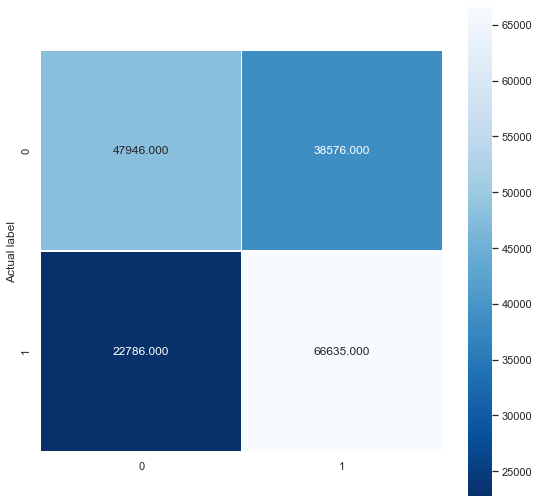

```python
cm_gbt = confusion_matrix(ytest, predictions)

plt.figure(figsize=(9,9))
sns.heatmap(cm_gbt, annot=True, fmt=".3f", linewidths=.5, square = True, cmap = 'Blues_r');
plt.ylabel('Actual label');
```

```
Confusion matrix, without normalization
[[47946 38576]
 [22786 66635]]
Normalized confusion matrix
[[0.55414808 0.44585192]
 [0.2548171  0.7451829 ]]
```

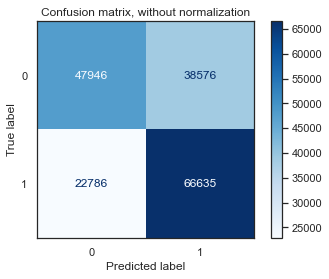

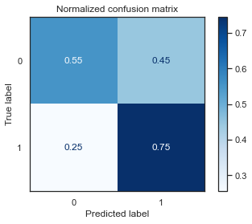

```python
# Plot non-normalized confusion matrix
titles_options = [("Confusion matrix, without normalization", None),
                  ("Normalized confusion matrix", 'true')]
for title, normalize in titles_options:
    disp = plot_confusion_matrix(CV, xtest, ytest,
                                 # display_labels=ytest,
                                 cmap=plt.cm.Blues,
                                 normalize=normalize)
    disp.ax_.set_title(title)

    print(title)
    print(disp.confusion_matrix)

plt.show()
```

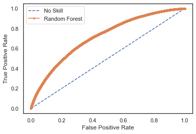

```python
# keep probabilities for the positive outcome only
yhat = prob_predictions[:, 1]
# calculate roc curves
fpr, tpr, thresholds = roc_curve(ytest, yhat)
# plot the roc curve for the model
plt.plot([0,1], [0,1], linestyle='--', label='No Skill')
plt.plot(fpr, tpr, marker='.', label='Random Forest')
# axis labels
plt.xlabel('False Positive Rate')
plt.ylabel('True Positive Rate')
plt.legend()
# show the plot
plt.show()
```

```python
# calculate the g-mean for each threshold
gmeans = np.sqrt(tpr * (1-fpr))
```

```python
# locate the index of the largest g-mean
ix = np.argmax(gmeans)
print('Best Threshold=%f, G-Mean=%.3f' % (thresholds[ix], gmeans[ix]))
```

```
Best Threshold=0.526249, G-Mean=0.657
```

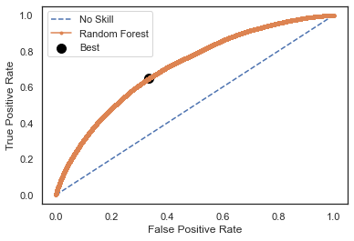

```python
# plot the roc curve for the model
plt.plot([0,1], [0,1], linestyle='--', label='No Skill')
plt.plot(fpr, tpr, marker='.', label='Random Forest')
plt.scatter(fpr[ix], tpr[ix], s=100, marker='o', color='black', label='Best')
# axis labels
plt.xlabel('False Positive Rate')
plt.ylabel('True Positive Rate')
plt.legend()
# show the plot
plt.show()
```

```python
# calculate pr-curve
precision, recall, thresholds = precision_recall_curve(ytest, yhat)
```

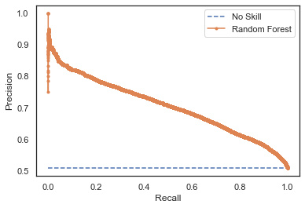

```python
# plot the roc curve for the model
no_skill = len(ytest[ytest==1]) / len(ytest)
plt.plot([0,1], [no_skill,no_skill], linestyle='--', label='No Skill')
plt.plot(recall, precision, marker='.', label='Random Forest')
# axis labels
plt.xlabel('Recall')
plt.ylabel('Precision')
plt.legend()
# show the plot
plt.show()
```

```
Best Threshold=0.433491, F-Score=0.707
```

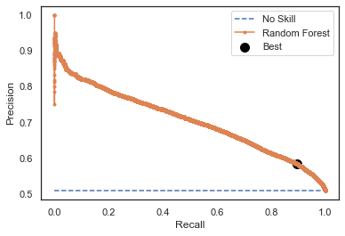

```python
# convert to f score
fscore = (2 * precision * recall) / (precision + recall)
# locate the index of the largest f score
ix = np.argmax(fscore)
print('Best Threshold=%f, F-Score=%.3f' % (thresholds[ix], fscore[ix]))
# plot the roc curve for the model
no_skill = len(ytest[ytest==1]) / len(ytest)
plt.plot([0,1], [no_skill,no_skill], linestyle='--', label='No Skill')
plt.plot(recall, precision, marker='.', label='Random Forest')
plt.scatter(recall[ix], precision[ix], s=100, marker='o', color='black', label='Best')
# axis labels
plt.xlabel('Recall')
plt.ylabel('Precision')
plt.legend()
# show the plot
plt.show()
```

```python
# evaluate the model
score = f1_score(ytest, predictions)
print('F-Score: %.5f' % score)
```

```
F-Score: 0.68473
```

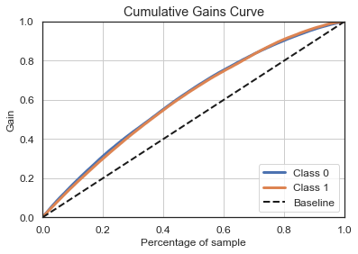

```python
import scikitplot as skplt
import matplotlib.pyplot as plt

skplt.metrics.plot_cumulative_gain(ytest, prob_predictions)
plt.show()
```

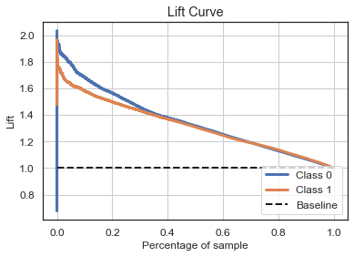

```python
skplt.metrics.plot_lift_curve(ytest, prob_predictions)
plt.show()
```

## Evaluación de modelos

Para poder elegir el modelo adecuado, hace falta para cada modelo candidato a solución:

1. Matriz de confusión, normalizada y sin normalizar.
2. Curva ROC
3. Curva de ganancia.
4. Curva Lift.
5. Jugar con distintos umbrales analizando cómo cambia el resultado.
6. Importante: **Partial Dependence Plots**, de esto último no damos ejemplos, debe buscar información por ti mismo, pero debe aparecer.

Lo normal es probar varios modelos, en ese caso, deberá aparecer una tabla comparando los diferentes modelos entre sí de acuerdo a sus métricas (recall, f1, etc.).

# Bloque 4: explicabilidad

Hoy en día, por temas de ética y regulación. La explicabilidad es tan importante que hemos decidido dedicarla un bloque aparte. Aquí podemos usar:

1. Información de la importancia de variables que devuelven algoritmos como RF o xgboost.
2. SHAP
3. LIME

Cuanto más completo mejor, una buena referencia: https://christophm.github.io/interpretable-ml-book/

```python
# https://github.com/slundberg/shap
import shap # cada notebook tendría sus respectivos import al inicio para mejor organización

# load JS visualization code to notebook
shap.initjs()
```

```python
explainer = shap.TreeExplainer(CV.best_estimator_.named_steps['classifier'])
```

```python
preprocessor = rf.named_steps["preprocessor"]
```

```python
import warnings

def get_feature_names(column_transformer):
    """Get feature names from all transformers.
    Returns
    -------
    feature_names : list of strings
        Names of the features produced by transform.
    """
    # Remove the internal helper function
    #check_is_fitted(column_transformer)

    # Turn loopkup into function for better handling with pipeline later
    def get_names(trans):
        # >> Original get_feature_names() method
        if trans == 'drop' or (
                hasattr(column, '__len__') and not len(column)):
            return []
        if trans == 'passthrough':
            if hasattr(column_transformer, '_df_columns'):
                if ((not isinstance(column, slice))
                        and all(isinstance(col, str) for col in column)):
                    return column
                else:
                    return column_transformer._df_columns[column]
            else:
                indices = np.arange(column_transformer._n_features)
                return ['x%d' % i for i in indices[column]]
        if not hasattr(trans, 'get_feature_names'):
        # >>> Change: Return input column names if no method avaiable
            # Turn error into a warning
            warnings.warn("Transformer %s (type %s) does not "
                                 "provide get_feature_names. "
                                 "Will return input column names if available"
                                 % (str(name), type(trans).__name__))
            # For transformers without a get_features_names method, use the input
            # names to the column transformer
            if column is None:
                return []
            else:
                return [name + "__" + f for f in column]

        return [name + "__" + f for f in trans.get_feature_names()]

    ### Start of processing
    feature_names = []

    # Allow transformers to be pipelines. Pipeline steps are named differently, so preprocessing is needed
    if type(column_transformer) == sklearn.pipeline.Pipeline:
        l_transformers = [(name, trans, None, None) for step, name, trans in column_transformer._iter()]
    else:
        # For column transformers, follow the original method
        l_transformers = list(column_transformer._iter(fitted=True))


    for name, trans, column, _ in l_transformers:
        if type(trans) == sklearn.pipeline.Pipeline:
            # Recursive call on pipeline
            _names = get_feature_names(trans)
            # if pipeline has no transformer that returns names
            if len(_names)==0:
                _names = [name + "__" + f for f in column]
            feature_names.extend(_names)
        else:
            feature_names.extend(get_names(trans))

    return feature_names
```

```python
all_columns = get_feature_names(preprocessor)
```

```python
len(all_columns)
```

```
151
```

```python
test_data = pd.DataFrame.sparse.from_spmatrix(rf['preprocessor'].transform(xtest))
```

```python
test_data.columns = all_columns
```

```python
test_data.head()
```

|  | num__loan_amnt | num__funded_amnt | num__funded_amnt_inv | num__term | num__int_rate | num__installment | num__emp_length | num__annual_inc | num__verification_status | num__dti | num__delinq_2yrs | num__fico_range_low | num__fico_range_high | num__open_acc | num__pub_rec | num__revol_bal | num__revol_util | num__total_acc | num__initial_list_status | num__application_type | num__acc_open_past_24mths | num__mort_acc | num__pub_rec_bankruptcies | num__tax_liens | num__disbursement_method | num__issue_year | num__earliest_cr_year | num__credit_history | onehot__x0_A | … |
| --- | --- | --- | --- | --- | --- | --- | --- | --- | --- | --- | --- | --- | --- | --- | --- | --- | --- | --- | --- | --- | --- | --- | --- | --- | --- | --- | --- | --- | --- | --- |
| 0 | 1.541374 | 1.541374 | 1.542705 | 1.470887 | 3.525819 | 1.853058 | 1.151390 | 0.096755 | 1.655779 | 0.362853 | -0.377490 | -0.361410 | -0.361407 | 0.559315 | 1.203170 | 0.322854 | 0.314748 | 0.252684 | 0.886329 | -0.043283 | -0.005853 | -0.323518 | 2.102023 | -0.143869 | -0.004963 | 3.815092 | 0.755030 | -0.435422 | 0.0 | … |
| 1 | -0.577937 | -0.577937 | -0.577479 | -0.679862 | 0.485613 | -0.371117 | -1.524651 | -0.690779 | -0.603945 | 1.213375 | -0.377490 | -0.009165 | -0.009168 | -0.894217 | 2.797594 | -0.551185 | 0.153990 | -0.567248 | 0.886329 | -0.043283 | 0.613814 | -0.817530 | 2.102023 | -0.143869 | -0.004963 | -0.971461 | 0.486310 | -0.570297 | 0.0 | … |
| 2 | -0.577937 | -0.577937 | -0.577479 | -0.679862 | -0.162731 | -0.429020 | 1.151390 | -0.218258 | -0.603945 | -1.680223 | -0.377490 | -1.065900 | -1.065885 | -0.712525 | 1.203170 | -0.551424 | -1.026309 | 0.252684 | 0.886329 | -0.043283 | -1.245187 | 0.664505 | 2.102023 | -0.143869 | -0.004963 | 0.624057 | 0.486310 | -0.435422 | 0.0 | … |
| 3 | 1.659114 | 1.659114 | 1.660493 | 1.470887 | 1.274139 | 1.283709 | -1.257047 | 0.096755 | 1.655779 | -0.574317 | 0.705177 | 1.223693 | 1.223670 | 0.014241 | -0.391253 | -0.646473 | -1.868171 | -0.403262 | 0.886329 | -0.043283 | -0.315686 | -0.323518 | -0.376092 | -0.143869 | -0.004963 | 0.624057 | 0.755030 | -0.705173 | 0.0 | … |
| 4 | 2.365551 | 2.365551 | 2.367221 | 1.470887 | -0.020358 | 1.473706 | 1.151390 | 0.928420 | -0.603945 | -0.903809 | -0.377490 | 0.519203 | 0.519191 | -0.167451 | -0.391253 | -0.588621 | -1.415511 | -0.075289 | 0.886329 | -0.043283 | 0.613814 | 0.664505 | -0.376092 | -0.143869 | -0.004963 | -0.971461 | -0.051131 | -0.030794 | 0.0 | … |

```python
shap_values = explainer.shap_values(test_data)
```

```python
test_data.iloc[0,:]
```

```
num__loan_amnt                   1.541374
num__funded_amnt                 1.541374
num__funded_amnt_inv             1.542705
num__term                        1.470887
num__int_rate                    3.525819
num__installment                 1.853058
num__emp_length                  1.151390
num__annual_inc                  0.096755
num__verification_status         1.655779
num__dti                         0.362853
num__delinq_2yrs                -0.377490
num__fico_range_low             -0.361410
num__fico_range_high            -0.361407
num__open_acc                    0.559315
num__pub_rec                     1.203170
num__revol_bal                   0.322854
num__revol_util                  0.314748
num__total_acc                   0.252684
num__initial_list_status         0.886329
num__application_type           -0.043283
num__acc_open_past_24mths       -0.005853
num__mort_acc                   -0.323518
num__pub_rec_bankruptcies        2.102023
num__tax_liens                  -0.143869
num__disbursement_method        -0.004963
num__issue_year                  3.815092
num__earliest_cr_year            0.755030
num__credit_history             -0.435422
onehot__x0_A                     0.000000
onehot__x0_B                     0.000000
onehot__x0_C                     0.000000
onehot__x0_D                     0.000000
onehot__x0_E                     0.000000
onehot__x0_F                     1.000000
onehot__x0_G                     0.000000
onehot__x1_A1                    0.000000
onehot__x1_A2                    0.000000
onehot__x1_A3                    0.000000
onehot__x1_A4                    0.000000
onehot__x1_A5                    0.000000
```

[output cut: 97 more lines]

```
onehot__x4_WV                    0.000000
onehot__x4_WY                    0.000000
onehot__x5_Apr                   0.000000
onehot__x5_Aug                   1.000000
onehot__x5_Dec                   0.000000
onehot__x5_Feb                   0.000000
onehot__x5_Jan                   0.000000
onehot__x5_Jul                   0.000000
onehot__x5_Jun                   0.000000
onehot__x5_Mar                   0.000000
onehot__x5_May                   0.000000
onehot__x5_Nov                   0.000000
onehot__x5_Oct                   0.000000
onehot__x5_Sep                   0.000000
Name: 0, dtype: Sparse[float64, 0]
```

```python
len(shap_values[0][0])
```

```
151
```

```python
# visualize the first prediction's explanation (use matplotlib=True to avoid Javascript)
shap.force_plot(explainer.expected_value[0], shap_values[0][0], test_data.iloc[0,:])
```

```python
shap.force_plot(explainer.expected_value[0], shap_values[0][:100,:], features=test_data.iloc[:100, :])
```

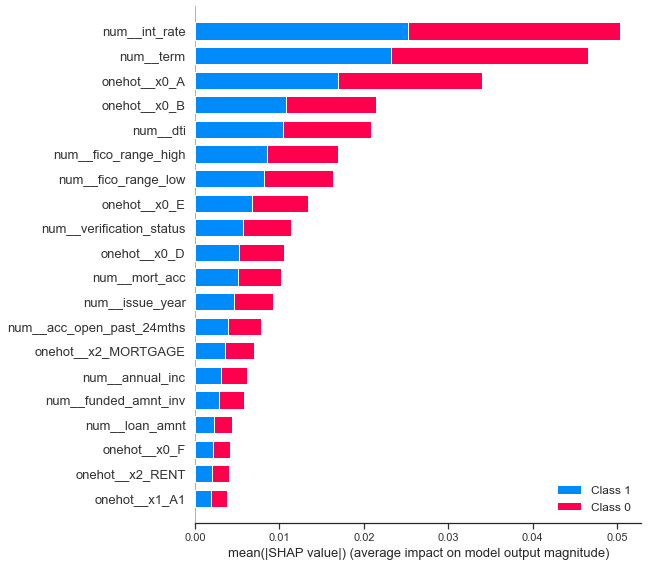

```python
# summarize the effects of all the features
shap.summary_plot(shap_values, test_data)
```

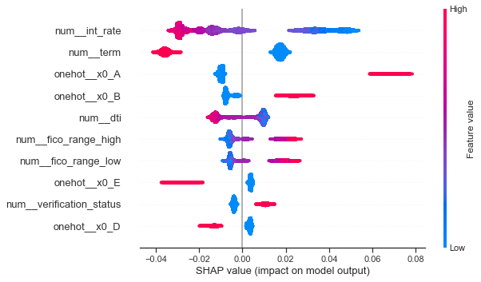

```python
shap.summary_plot(shap_values[0], features=test_data, max_display=10)
```

Recuerda que esto es una guía, el código no es productivo, es para que te sirva de ejemplo. Debes hacer un esfuerzo para interpretarlo. Obligatorio analizar cada gráfico y sacar conclusiones de ahí, ¿qué nos está diciendo?

**Para nota**

Evaluar y explicar estas herramientas empleándolas en tu proyecto:

https://www.tensorflow.org/responsible_ai/fairness_indicators/guide?hl=en

https://pair-code.github.io/what-if-tool/

# Bloque 5: puesta en producción

Aquí ya entramos en la parte de nota alta (SB y MH). Poner en producción un modelo de ML muchas veces es un reto. Como ejercicio opciones pero necesario para obtener la máxima calificación, te proponemos estudiar la apificación del modelo creado usando flask.

https://towardsdatascience.com/how-to-build-a-machine-learning-api-using-flask-2fb345518801

Una puesta en producción debe incluir una monitorización detallada de lo que está pasando. En esta asignatura y por falta de tiempo lo obviaremos, pero para el TFM lo deberías considerar. La API debe dejar unos registros de logs que serán la información de entrada para algún tipo de visualización (con Tableau o Power BI por ejemplo) mostrando lo que está pasando.

[figure not shown]